# HW3_Statistical Machine Learning

Moran Guo

2024-10-01

## Question 1 (10.7-8)

### (a)

```r
# Load required packages
library(ISLR)

pr_out <- prcomp(USArrests, center = TRUE, scale = TRUE)
pve <- pr_out$sdev^2 / sum(pr_out$sdev^2) # Eq. (10.8)
pve
```

```
## [1] 0.62006039 0.24744129 0.08914080 0.04335752
```

### (b)

To obtain the PVE directly, we consider the equation $(10.8)$. The numerator indicates that we need to multiply the loading vector matrix with the scaled/non-scaled data matrix, take the square of the product, and finally obtain the column summation. The denominator is just the summation of data matrix squared.

```r
loading <- pr_out$rotation # Obtain the loading vector
data_m <- scale(USArrests)
pve_alt <- colSums((as.matrix(data_m) %*% loading)^2)/sum(data_m^2)
pve_alt
```

```
##        PC1        PC2        PC3        PC4
## 0.62006039 0.24744129 0.08914080 0.04335752
```

We can see that the two options for calculating PVE yield the same results.

## Question 2 (10.7-9)

### (a)

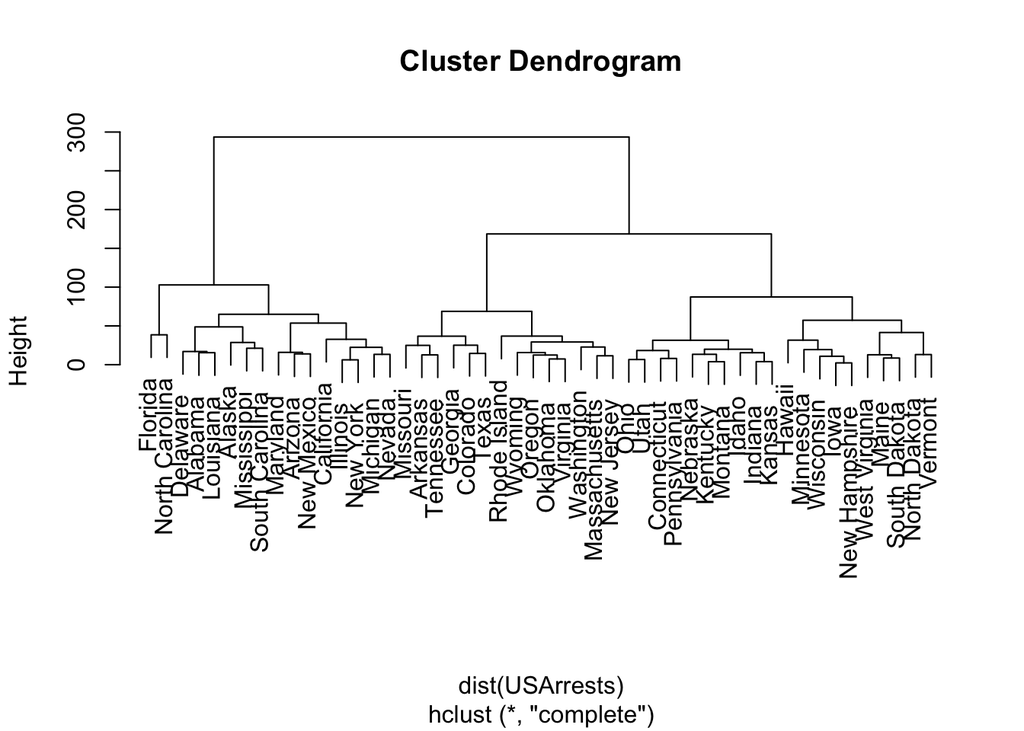

```r
# Load required packages
library(ISLR)

set.seed(644)

hc_complete <- hclust(dist(USArrests), method = "complete")

plot(hc_complete)
```

### (b)

```r
hc_cut_3 <- cutree(hc_complete, 3)
hc_cut_3
```

```
##        Alabama         Alaska        Arizona       Arkansas     California
##              1              1              1              2              1
##       Colorado    Connecticut       Delaware        Florida        Georgia
##              2              3              1              1              2
##         Hawaii          Idaho       Illinois        Indiana           Iowa
##              3              3              1              3              3
##         Kansas       Kentucky      Louisiana          Maine       Maryland
##              3              3              1              3              1
##  Massachusetts       Michigan      Minnesota    Mississippi       Missouri
##              2              1              3              1              2
##        Montana       Nebraska         Nevada  New Hampshire     New Jersey
##              3              3              1              3              2
##     New Mexico       New York North Carolina   North Dakota           Ohio
##              1              1              1              3              3
##       Oklahoma         Oregon   Pennsylvania   Rhode Island South Carolina
##              2              2              3              2              1
##   South Dakota      Tennessee          Texas           Utah        Vermont
##              3              2              2              3              3
##       Virginia     Washington  West Virginia      Wisconsin        Wyoming
##              2              2              3              3              2
```

### (c)

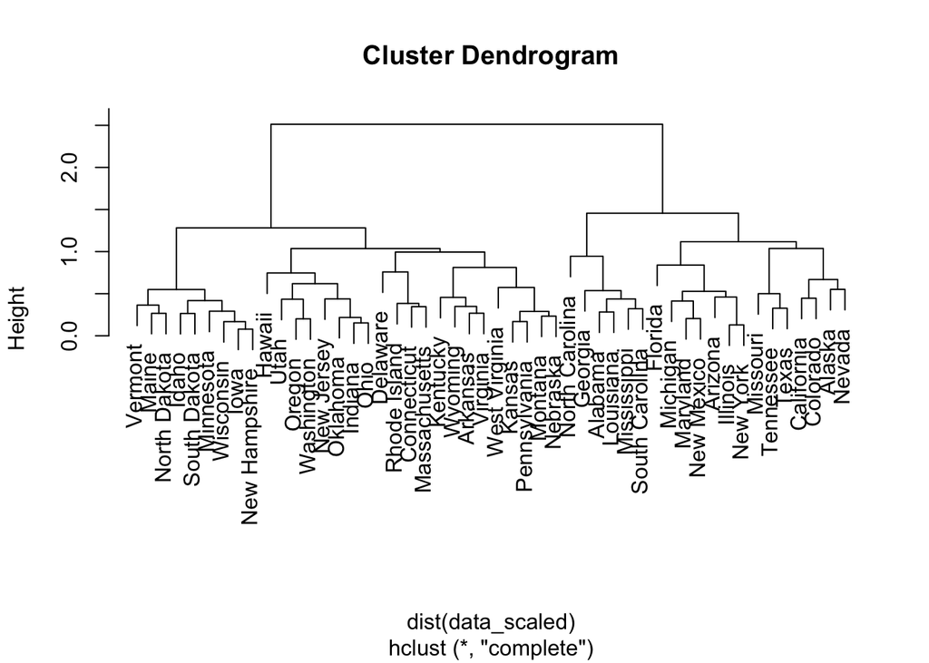

```r
data_scaled <- scale(USArrests, center = FALSE)

hc_scaled <- hclust(dist(data_scaled), method = "complete")

plot(hc_scaled)
```

### (d)

We check the labeled clusters for each state and their agreement:

```r
hc_scaled_cut_3 <- cutree(hc_scaled, 3)

hc_scaled_cut_3
```

```
##        Alabama         Alaska        Arizona       Arkansas     California
##              1              2              2              3              2
##       Colorado    Connecticut       Delaware        Florida        Georgia
##              2              3              3              2              1
##         Hawaii          Idaho       Illinois        Indiana           Iowa
##              3              3              2              3              3
##         Kansas       Kentucky      Louisiana          Maine       Maryland
##              3              3              1              3              2
##  Massachusetts       Michigan      Minnesota    Mississippi       Missouri
##              3              2              3              1              2
##        Montana       Nebraska         Nevada  New Hampshire     New Jersey
##              3              3              2              3              3
##     New Mexico       New York North Carolina   North Dakota           Ohio
##              2              2              1              3              3
##       Oklahoma         Oregon   Pennsylvania   Rhode Island South Carolina
##              3              3              3              3              1
##   South Dakota      Tennessee          Texas           Utah        Vermont
##              3              2              2              3              3
##       Virginia     Washington  West Virginia      Wisconsin        Wyoming
##              3              3              3              3              3
```

```r
table(hc_scaled_cut_3, hc_cut_3)
```

```
##                hc_cut_3
## hc_scaled_cut_3  1  2  3
##               1  5  1  0
##               2 10  4  0
##               3  1  9 20
```

```r
USArrests
```

```
##                Murder Assault UrbanPop Rape
## Alabama          13.2     236       58 21.2
## Alaska           10.0     263       48 44.5
## Arizona           8.1     294       80 31.0
## Arkansas          8.8     190       50 19.5
## California        9.0     276       91 40.6
## Colorado          7.9     204       78 38.7
## Connecticut       3.3     110       77 11.1
## Delaware          5.9     238       72 15.8
## Florida          15.4     335       80 31.9
## Georgia          17.4     211       60 25.8
## Hawaii            5.3      46       83 20.2
## Idaho             2.6     120       54 14.2
## Illinois         10.4     249       83 24.0
## Indiana           7.2     113       65 21.0
## Iowa              2.2      56       57 11.3
## Kansas            6.0     115       66 18.0
## Kentucky          9.7     109       52 16.3
## Louisiana        15.4     249       66 22.2
## Maine             2.1      83       51  7.8
## Maryland         11.3     300       67 27.8
## Massachusetts     4.4     149       85 16.3
## Michigan         12.1     255       74 35.1
## Minnesota         2.7      72       66 14.9
## Mississippi      16.1     259       44 17.1
## Missouri          9.0     178       70 28.2
## Montana           6.0     109       53 16.4
## Nebraska          4.3     102       62 16.5
## Nevada           12.2     252       81 46.0
## New Hampshire     2.1      57       56  9.5
## New Jersey        7.4     159       89 18.8
## New Mexico       11.4     285       70 32.1
## New York         11.1     254       86 26.1
## North Carolina   13.0     337       45 16.1
## North Dakota      0.8      45       44  7.3
## Ohio              7.3     120       75 21.4
## Oklahoma          6.6     151       68 20.0
## Oregon            4.9     159       67 29.3
## Pennsylvania      6.3     106       72 14.9
## Rhode Island      3.4     174       87  8.3
## South Carolina   14.4     279       48 22.5
## South Dakota      3.8      86       45 12.8
## Tennessee        13.2     188       59 26.9
## Texas            12.7     201       80 25.5
## Utah              3.2     120       80 22.9
## Vermont           2.2      48       32 11.2
## Virginia          8.5     156       63 20.7
## Washington        4.0     145       73 26.2
## West Virginia     5.7      81       39  9.3
## Wisconsin         2.6      53       66 10.8
## Wyoming           6.8     161       60 15.6
```

Observing the `USArrests` dataset, we found that the `Assault` column representing assault rates inherently has larger variance than the other two features, thus the pairwise Euclidean distance is dominated by `Assault` variable. Therefore, scaling is necessary. Scaling ensures that all four variables have similar contributions to the Euclidean distances, and that’s the reason why we are seeing discrepancies between the two hierarchical clustering results. Moreover, the variable `UrbanPop` has different unit than the rest variables, which further rationalizes the scaling.

So I conclude that the variable should be scaled based on the above reasons.

## Question 3 (10.7-11)

### (a)

```r
setwd("~/JHSPH_Stat_ML/")
data <- read.csv("./Ch10Ex11.csv", header = FALSE)
#data
```

### (b)

```r
correlation_d <- as.dist(1 - cor(data))

sample_status <- gl(2, 20) # label vectors

hc_complete <- hclust(correlation_d, method = "complete")
#Complete linkage

table(sample_status, cutree(hc_complete, k = 2))
```

```
##
## sample_status  1  2
##             1 10 10
##             2  0 20
```

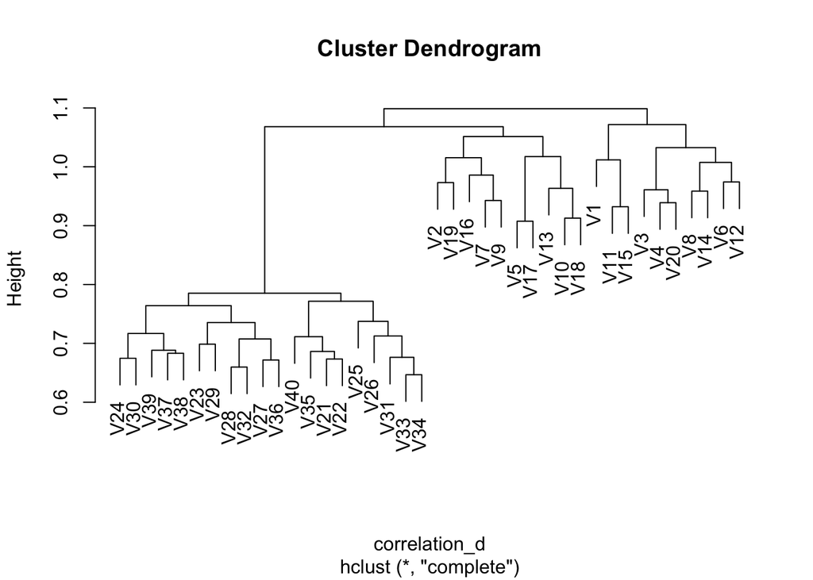

```r
plot(hc_complete)
```

To test for whether or not the result depends on linkage types, we do:

```r
hc_average <- hclust(correlation_d, method = "average")
#Average linkage
table(sample_status, cutree(hc_average, k = 2))
```

```
##
## sample_status  1  2
##             1  9 11
##             2  0 20
```

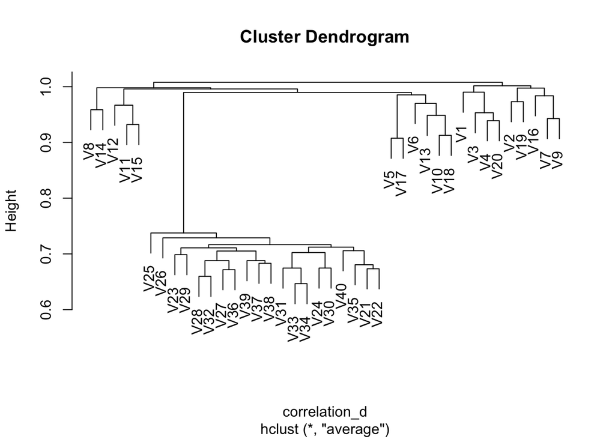

```r
plot(hc_average)
```

```r
hc_single <- hclust(correlation_d, method = "single")
#Single linkage
table(sample_status, cutree(hc_single, k = 2))
```

```
##
## sample_status  1  2
##             1 19  1
##             2 20  0
```

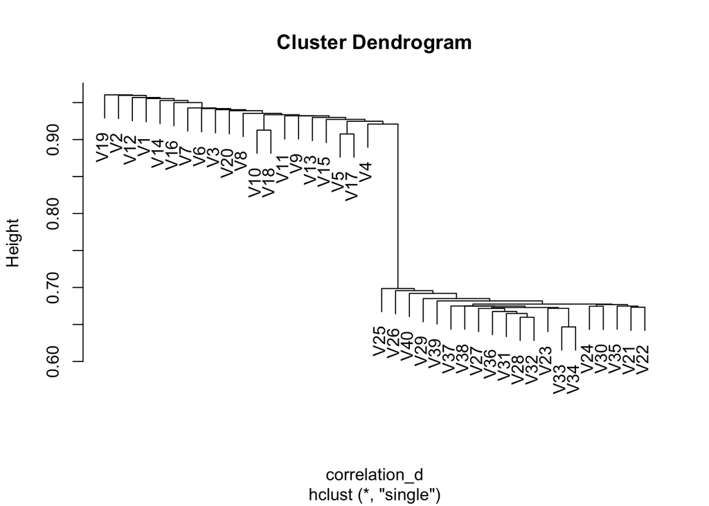

```r
plot(hc_single)
```

### (c)

To give a best representation of which genes differ the most, we can do the following: 1. Calculate the absolute mean difference between the healthy and diseased individuals, and 2. Do a 2-sample t-test between the two groups.

```r
rownames(data) = paste0("gene", 1:1000)
healthy_data <- data[, 1:20]
diseased_data <- data[, 21:40]

healthy_means <- rowMeans(healthy_data)
diseased_means <- rowMeans(diseased_data)


abs_mean_diff <- sort(abs(healthy_means - diseased_means),
                      decreasing = TRUE)[1:5]
abs_mean_diff
```

```
##  gene600  gene584  gene549  gene540  gene502
## 2.747577 2.601985 2.550757 2.545174 2.544461
```

```r
p_val <- rep(NA, nrow(data))

for (i in 1:nrow(data)) {
  healthy_data <- data[i, 1:20]
  diseased_data <- data[i, 21:40]
  p_val[i] <- t.test(healthy_data, diseased_data)$p.value
}

top_genes <- order(p_val)[1:5]

gene_names <- rownames(data)[top_genes]
gene_names
```

```
## [1] "gene502" "gene589" "gene600" "gene590" "gene565"
```

```r
p_val[top_genes]
```

```
## [1] 1.530472e-12 6.511864e-12 1.003599e-11 1.123456e-10 1.765864e-10
```

From the result of `abs_mean_diff` and `top_genes`, we can see that `gene600`, `gene502` are on the top of both lists, so they differ the most overall across the two groups, `healthy` and `diseased` individuals.